# Risk Factor Analysis

## Outcome Variable

**Outcome Variable:** ever_stunted

## Predictor Variables

**Intervention Variable:** perdiar6

**Adjustment Set:**

- arm
- W_mage
- meducyrs
- feducyrs
- hhwealth_quart
- hfoodsec
- W_mhtcm
- W_mwtkg
- W_mbmi
- W_birthwt
- W_birthlen
- W_nrooms
- month
- brthmon
- impfloor
- impsan
- safeh20
- delta_W_mage
- delta_meducyrs
- delta_feducyrs
- delta_hhwealth_quart
- delta_hfoodsec
- delta_W_mhtcm
- delta_W_mwtkg
- delta_W_mbmi
- delta_W_birthwt
- delta_W_birthlen
- delta_W_nrooms
- delta_month
- delta_brthmon
- delta_impfloor
- delta_impsan
- delta_safeh20

## Stratifying Variables

The analysis was stratified on these variable(s):

- agecat
- studyid
- country

## Data Summary

| agecat | studyid | country | perdiar6 | ever_stunted | n_cell | n |
| --- | --- | --- | --- | --- | --- | --- |
| 0-24 months (no birth st.) | CMIN | BANGLADESH | 0% | 0 | 20 | 168 |
| 0-24 months (no birth st.) | CMIN | BANGLADESH | 0% | 1 | 48 | 168 |
| 0-24 months (no birth st.) | CMIN | BANGLADESH | (0%, 5%] | 0 | 5 | 168 |
| 0-24 months (no birth st.) | CMIN | BANGLADESH | (0%, 5%] | 1 | 29 | 168 |
| 0-24 months (no birth st.) | CMIN | BANGLADESH | >5% | 0 | 16 | 168 |
| 0-24 months (no birth st.) | CMIN | BANGLADESH | >5% | 1 | 50 | 168 |
| 0-24 months (no birth st.) | CONTENT | PERU | 0% | 0 | 84 | 195 |
| 0-24 months (no birth st.) | CONTENT | PERU | 0% | 1 | 19 | 195 |
| 0-24 months (no birth st.) | CONTENT | PERU | (0%, 5%] | 0 | 31 | 195 |
| 0-24 months (no birth st.) | CONTENT | PERU | (0%, 5%] | 1 | 6 | 195 |
| 0-24 months (no birth st.) | CONTENT | PERU | >5% | 0 | 47 | 195 |
| 0-24 months (no birth st.) | CONTENT | PERU | >5% | 1 | 8 | 195 |
| 0-24 months (no birth st.) | EE | PAKISTAN | 0% | 0 | 38 | 213 |
| 0-24 months (no birth st.) | EE | PAKISTAN | 0% | 1 | 161 | 213 |
| 0-24 months (no birth st.) | EE | PAKISTAN | (0%, 5%] | 0 | 2 | 213 |
| 0-24 months (no birth st.) | EE | PAKISTAN | (0%, 5%] | 1 | 11 | 213 |
| 0-24 months (no birth st.) | EE | PAKISTAN | >5% | 0 | 1 | 213 |
| 0-24 months (no birth st.) | EE | PAKISTAN | >5% | 1 | 0 | 213 |
| 0-24 months (no birth st.) | MAL-ED | BANGLADESH | 0% | 0 | 35 | 217 |
| 0-24 months (no birth st.) | MAL-ED | BANGLADESH | 0% | 1 | 37 | 217 |
| 0-24 months (no birth st.) | MAL-ED | BANGLADESH | (0%, 5%] | 0 | 41 | 217 |
| 0-24 months (no birth st.) | MAL-ED | BANGLADESH | (0%, 5%] | 1 | 44 | 217 |
| 0-24 months (no birth st.) | MAL-ED | BANGLADESH | >5% | 0 | 27 | 217 |
| 0-24 months (no birth st.) | MAL-ED | BANGLADESH | >5% | 1 | 33 | 217 |
| 0-24 months (no birth st.) | MAL-ED | BRAZIL | 0% | 0 | 156 | 202 |
| 0-24 months (no birth st.) | MAL-ED | BRAZIL | 0% | 1 | 30 | 202 |
| 0-24 months (no birth st.) | MAL-ED | BRAZIL | (0%, 5%] | 0 | 12 | 202 |
| 0-24 months (no birth st.) | MAL-ED | BRAZIL | (0%, 5%] | 1 | 2 | 202 |
| 0-24 months (no birth st.) | MAL-ED | BRAZIL | >5% | 0 | 2 | 202 |
| 0-24 months (no birth st.) | MAL-ED | BRAZIL | >5% | 1 | 0 | 202 |

[output cut: 204 more lines]

The following strata were considered:

- agecat: 0-24 months (no birth st.), studyid: CMIN, country: BANGLADESH
- agecat: 0-24 months (no birth st.), studyid: CONTENT, country: PERU
- agecat: 0-24 months (no birth st.), studyid: EE, country: PAKISTAN
- agecat: 0-24 months (no birth st.), studyid: MAL-ED, country: BANGLADESH
- agecat: 0-24 months (no birth st.), studyid: MAL-ED, country: BRAZIL
- agecat: 0-24 months (no birth st.), studyid: MAL-ED, country: INDIA
- agecat: 0-24 months (no birth st.), studyid: MAL-ED, country: NEPAL
- agecat: 0-24 months (no birth st.), studyid: MAL-ED, country: PERU
- agecat: 0-24 months (no birth st.), studyid: MAL-ED, country: SOUTH AFRICA
- agecat: 0-24 months (no birth st.), studyid: MAL-ED, country: TANZANIA, UNITED REPUBLIC OF
- agecat: 0-24 months (no birth st.), studyid: NIH-Birth, country: BANGLADESH
- agecat: 0-24 months (no birth st.), studyid: NIH-Crypto, country: BANGLADESH
- agecat: 0-24 months (no birth st.), studyid: PROVIDE, country: BANGLADESH
- agecat: 0-6 months (no birth st.), studyid: CMIN, country: BANGLADESH
- agecat: 0-6 months (no birth st.), studyid: CONTENT, country: PERU
- agecat: 0-6 months (no birth st.), studyid: EE, country: PAKISTAN
- agecat: 0-6 months (no birth st.), studyid: MAL-ED, country: BANGLADESH
- agecat: 0-6 months (no birth st.), studyid: MAL-ED, country: BRAZIL
- agecat: 0-6 months (no birth st.), studyid: MAL-ED, country: INDIA
- agecat: 0-6 months (no birth st.), studyid: MAL-ED, country: NEPAL
- agecat: 0-6 months (no birth st.), studyid: MAL-ED, country: PERU
- agecat: 0-6 months (no birth st.), studyid: MAL-ED, country: SOUTH AFRICA
- agecat: 0-6 months (no birth st.), studyid: MAL-ED, country: TANZANIA, UNITED REPUBLIC OF
- agecat: 0-6 months (no birth st.), studyid: NIH-Birth, country: BANGLADESH
- agecat: 0-6 months (no birth st.), studyid: NIH-Crypto, country: BANGLADESH
- agecat: 0-6 months (no birth st.), studyid: PROVIDE, country: BANGLADESH
- agecat: 6-24 months, studyid: CMIN, country: BANGLADESH
- agecat: 6-24 months, studyid: CONTENT, country: PERU
- agecat: 6-24 months, studyid: EE, country: PAKISTAN
- agecat: 6-24 months, studyid: MAL-ED, country: BANGLADESH
- agecat: 6-24 months, studyid: MAL-ED, country: BRAZIL
- agecat: 6-24 months, studyid: MAL-ED, country: INDIA
- agecat: 6-24 months, studyid: MAL-ED, country: NEPAL
- agecat: 6-24 months, studyid: MAL-ED, country: PERU
- agecat: 6-24 months, studyid: MAL-ED, country: SOUTH AFRICA
- agecat: 6-24 months, studyid: MAL-ED, country: TANZANIA, UNITED REPUBLIC OF
- agecat: 6-24 months, studyid: NIH-Birth, country: BANGLADESH
- agecat: 6-24 months, studyid: NIH-Crypto, country: BANGLADESH
- agecat: 6-24 months, studyid: PROVIDE, country: BANGLADESH

### Dropped Strata

Some strata were dropped due to rare outcomes:

- agecat: 0-24 months (no birth st.), studyid: EE, country: PAKISTAN
- agecat: 0-24 months (no birth st.), studyid: MAL-ED, country: BRAZIL
- agecat: 0-24 months (no birth st.), studyid: MAL-ED, country: SOUTH AFRICA
- agecat: 0-6 months (no birth st.), studyid: CONTENT, country: PERU
- agecat: 0-6 months (no birth st.), studyid: EE, country: PAKISTAN
- agecat: 0-6 months (no birth st.), studyid: MAL-ED, country: BRAZIL
- agecat: 0-6 months (no birth st.), studyid: MAL-ED, country: NEPAL
- agecat: 0-6 months (no birth st.), studyid: MAL-ED, country: SOUTH AFRICA
- agecat: 6-24 months, studyid: EE, country: PAKISTAN
- agecat: 6-24 months, studyid: MAL-ED, country: BRAZIL
- agecat: 6-24 months, studyid: MAL-ED, country: SOUTH AFRICA

## Methods Detail

We’re interested in the causal parameters $E[Y_a]$ for all values of $a \in \mathcal{A}$. These parameters represent the mean outcome if, possibly contrary to fact, we intervened to set all units to have $A=a$. Under the randomization and positivity assumptions, these are identified by the statistical parameters $\psi_a=E_W[E_{Y|A,W}(Y|A=a,W)]$. In addition, we’re interested in the mean of $Y$, $E[Y]$ under no intervention (the observed mean). We will estimate these parameters by using SuperLearner to fit the relevant likelihood factors – $E_{Y|A,W}(Y|A=a,W)$ and $p(A=a|W)$, and then updating our likelihood fit using a joint TMLE.

For unadjusted analyses ($W=\{\}$), initial likelihoods were estimated using Lrnr_glm to estimate the simple $E(Y|A)$ and Lrnr_mean to estimate $p(A)$. For adjusted analyses, a small library containing Lrnr_glmnet, Lrnr_xgboost, and Lrnr_mean was used.

Having estimated these parameters, we will then use the delta method to estimate relative risks and attributable risks relative to a prespecified baseline level of $A$.

# Results Detail

## Results Plots

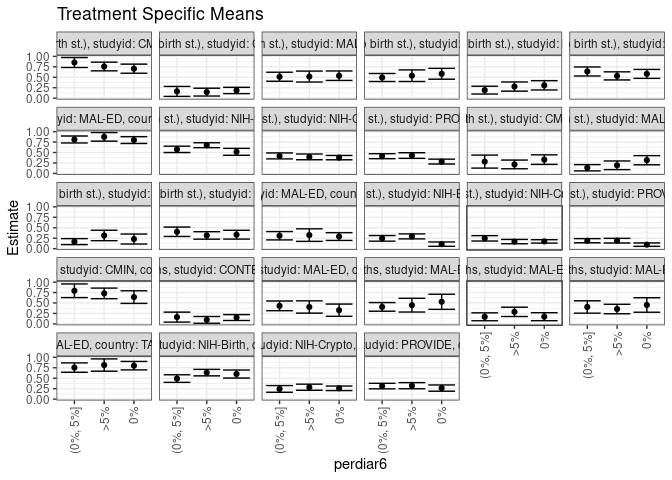

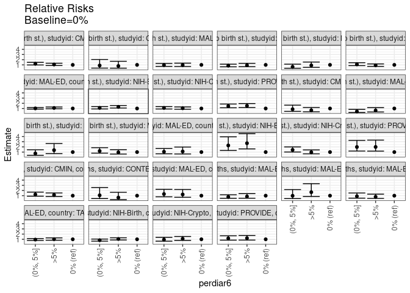

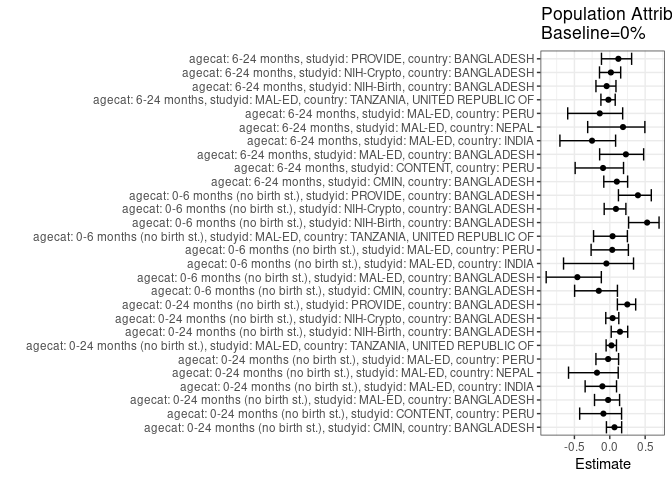

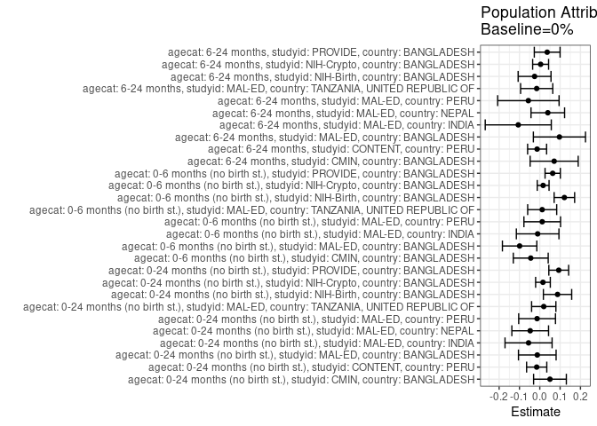

## Results Table

### Parameter: TSM

| agecat | studyid | country | intervention_level | baseline_level | estimate | ci_lower | ci_upper |
| --- | --- | --- | --- | --- | --- | --- | --- |
| 0-24 months (no birth st.) | CMIN | BANGLADESH | 0% | NA | 0.7058824 | 0.5972606 | 0.8145041 |
| 0-24 months (no birth st.) | CMIN | BANGLADESH | (0%, 5%] | NA | 0.8529412 | 0.7335396 | 0.9723428 |
| 0-24 months (no birth st.) | CMIN | BANGLADESH | >5% | NA | 0.7575758 | 0.6538770 | 0.8612745 |
| 0-24 months (no birth st.) | CONTENT | PERU | 0% | NA | 0.1844660 | 0.1093686 | 0.2595635 |
| 0-24 months (no birth st.) | CONTENT | PERU | (0%, 5%] | NA | 0.1621622 | 0.0430878 | 0.2812366 |
| 0-24 months (no birth st.) | CONTENT | PERU | >5% | NA | 0.1454545 | 0.0520400 | 0.2388691 |
| 0-24 months (no birth st.) | MAL-ED | BANGLADESH | 0% | NA | 0.5377071 | 0.4247641 | 0.6506501 |
| 0-24 months (no birth st.) | MAL-ED | BANGLADESH | (0%, 5%] | NA | 0.5125884 | 0.4045210 | 0.6206559 |
| 0-24 months (no birth st.) | MAL-ED | BANGLADESH | >5% | NA | 0.5166917 | 0.3858989 | 0.6474845 |
| 0-24 months (no birth st.) | MAL-ED | INDIA | 0% | NA | 0.5838488 | 0.4544131 | 0.7132846 |
| 0-24 months (no birth st.) | MAL-ED | INDIA | (0%, 5%] | NA | 0.4946819 | 0.3992338 | 0.5901301 |
| 0-24 months (no birth st.) | MAL-ED | INDIA | >5% | NA | 0.5380437 | 0.3994773 | 0.6766101 |
| 0-24 months (no birth st.) | MAL-ED | NEPAL | 0% | NA | 0.3078339 | 0.1966578 | 0.4190100 |
| 0-24 months (no birth st.) | MAL-ED | NEPAL | (0%, 5%] | NA | 0.1928192 | 0.0998692 | 0.2857691 |
| 0-24 months (no birth st.) | MAL-ED | NEPAL | >5% | NA | 0.2786004 | 0.1689614 | 0.3882393 |
| 0-24 months (no birth st.) | MAL-ED | PERU | 0% | NA | 0.5809414 | 0.4744179 | 0.6874649 |
| 0-24 months (no birth st.) | MAL-ED | PERU | (0%, 5%] | NA | 0.6392834 | 0.5318971 | 0.7466697 |
| 0-24 months (no birth st.) | MAL-ED | PERU | >5% | NA | 0.5334680 | 0.4364729 | 0.6304631 |
| 0-24 months (no birth st.) | MAL-ED | TANZANIA, UNITED REPUBLIC OF | 0% | NA | 0.7978723 | 0.7165036 | 0.8792411 |
| 0-24 months (no birth st.) | MAL-ED | TANZANIA, UNITED REPUBLIC OF | (0%, 5%] | NA | 0.8117647 | 0.7284737 | 0.8950557 |
| 0-24 months (no birth st.) | MAL-ED | TANZANIA, UNITED REPUBLIC OF | >5% | NA | 0.8750000 | 0.7722762 | 0.9777238 |
| 0-24 months (no birth st.) | NIH-Birth | BANGLADESH | 0% | NA | 0.5168645 | 0.4340656 | 0.5996634 |
| 0-24 months (no birth st.) | NIH-Birth | BANGLADESH | (0%, 5%] | NA | 0.5754524 | 0.4994979 | 0.6514068 |
| 0-24 months (no birth st.) | NIH-Birth | BANGLADESH | >5% | NA | 0.6745612 | 0.6159463 | 0.7331762 |
| 0-24 months (no birth st.) | NIH-Crypto | BANGLADESH | 0% | NA | 0.3779732 | 0.3260340 | 0.4299125 |
| 0-24 months (no birth st.) | NIH-Crypto | BANGLADESH | (0%, 5%] | NA | 0.4187380 | 0.3476132 | 0.4898628 |
| 0-24 months (no birth st.) | NIH-Crypto | BANGLADESH | >5% | NA | 0.3953065 | 0.3273972 | 0.4632158 |
| 0-24 months (no birth st.) | PROVIDE | BANGLADESH | 0% | NA | 0.2828657 | 0.2251871 | 0.3405443 |
| 0-24 months (no birth st.) | PROVIDE | BANGLADESH | (0%, 5%] | NA | 0.4118867 | 0.3517762 | 0.4719972 |
| 0-24 months (no birth st.) | PROVIDE | BANGLADESH | >5% | NA | 0.4274077 | 0.3597257 | 0.4950897 |

[output cut: 54 more lines]

### Parameter: E(Y)

| agecat | studyid | country | intervention_level | baseline_level | estimate | ci_lower | ci_upper |
| --- | --- | --- | --- | --- | --- | --- | --- |
| 0-24 months (no birth st.) | CMIN | BANGLADESH | NA | NA | 0.7559524 | 0.6908084 | 0.8210964 |
| 0-24 months (no birth st.) | CONTENT | PERU | NA | NA | 0.1692308 | 0.1164681 | 0.2219935 |
| 0-24 months (no birth st.) | MAL-ED | BANGLADESH | NA | NA | 0.5253456 | 0.4587520 | 0.5919392 |
| 0-24 months (no birth st.) | MAL-ED | INDIA | NA | NA | 0.5285714 | 0.4608954 | 0.5962474 |
| 0-24 months (no birth st.) | MAL-ED | NEPAL | NA | NA | 0.2606635 | 0.2012891 | 0.3200380 |
| 0-24 months (no birth st.) | MAL-ED | PERU | NA | NA | 0.5676692 | 0.5080232 | 0.6273151 |
| 0-24 months (no birth st.) | MAL-ED | TANZANIA, UNITED REPUBLIC OF | NA | NA | 0.8173516 | 0.7660617 | 0.8686415 |
| 0-24 months (no birth st.) | NIH-Birth | BANGLADESH | NA | NA | 0.6041667 | 0.5624147 | 0.6459187 |
| 0-24 months (no birth st.) | NIH-Crypto | BANGLADESH | NA | NA | 0.3935681 | 0.3560687 | 0.4310676 |
| 0-24 months (no birth st.) | PROVIDE | BANGLADESH | NA | NA | 0.3759874 | 0.3382238 | 0.4137509 |
| 0-6 months (no birth st.) | CMIN | BANGLADESH | NA | NA | 0.2857143 | 0.2171983 | 0.3542303 |
| 0-6 months (no birth st.) | MAL-ED | BANGLADESH | NA | NA | 0.2165899 | 0.1616567 | 0.2715231 |
| 0-6 months (no birth st.) | MAL-ED | INDIA | NA | NA | 0.2190476 | 0.1629743 | 0.2751210 |
| 0-6 months (no birth st.) | MAL-ED | PERU | NA | NA | 0.3458647 | 0.2885967 | 0.4031327 |
| 0-6 months (no birth st.) | MAL-ED | TANZANIA, UNITED REPUBLIC OF | NA | NA | 0.3013699 | 0.2404592 | 0.3622805 |
| 0-6 months (no birth st.) | NIH-Birth | BANGLADESH | NA | NA | 0.2291667 | 0.1932828 | 0.2650505 |
| 0-6 months (no birth st.) | NIH-Crypto | BANGLADESH | NA | NA | 0.1898928 | 0.1597870 | 0.2199986 |
| 0-6 months (no birth st.) | PROVIDE | BANGLADESH | NA | NA | 0.1595577 | 0.1310079 | 0.1881074 |
| 6-24 months | CMIN | BANGLADESH | NA | NA | 0.7117117 | 0.6270636 | 0.7963598 |
| 6-24 months | CONTENT | PERU | NA | NA | 0.1382979 | 0.0888197 | 0.1877760 |
| 6-24 months | MAL-ED | BANGLADESH | NA | NA | 0.4240506 | 0.3467471 | 0.5013542 |
| 6-24 months | MAL-ED | INDIA | NA | NA | 0.4220779 | 0.3438191 | 0.5003367 |
| 6-24 months | MAL-ED | NEPAL | NA | NA | 0.2113402 | 0.1537425 | 0.2689379 |
| 6-24 months | MAL-ED | PERU | NA | NA | 0.3959732 | 0.3171819 | 0.4747644 |
| 6-24 months | MAL-ED | TANZANIA, UNITED REPUBLIC OF | NA | NA | 0.7847222 | 0.7173567 | 0.8520877 |
| 6-24 months | NIH-Birth | BANGLADESH | NA | NA | 0.5739130 | 0.5216565 | 0.6261696 |
| 6-24 months | NIH-Crypto | BANGLADESH | NA | NA | 0.2628458 | 0.2244546 | 0.3012371 |
| 6-24 months | PROVIDE | BANGLADESH | NA | NA | 0.3004386 | 0.2583143 | 0.3425629 |

### Parameter: RR

| agecat | studyid | country | intervention_level | baseline_level | estimate | ci_lower | ci_upper |
| --- | --- | --- | --- | --- | --- | --- | --- |
| 0-24 months (no birth st.) | CMIN | BANGLADESH | 0% | 0% | 1.0000000 | 1.0000000 | 1.0000000 |
| 0-24 months (no birth st.) | CMIN | BANGLADESH | (0%, 5%] | 0% | 1.2083333 | 0.9813886 | 1.4877587 |
| 0-24 months (no birth st.) | CMIN | BANGLADESH | >5% | 0% | 1.0732323 | 0.8734742 | 1.3186739 |
| 0-24 months (no birth st.) | CONTENT | PERU | 0% | 0% | 1.0000000 | 1.0000000 | 1.0000000 |
| 0-24 months (no birth st.) | CONTENT | PERU | (0%, 5%] | 0% | 0.8790896 | 0.3796656 | 2.0354714 |
| 0-24 months (no birth st.) | CONTENT | PERU | >5% | 0% | 0.7885167 | 0.3686200 | 1.6867200 |
| 0-24 months (no birth st.) | MAL-ED | BANGLADESH | 0% | 0% | 1.0000000 | 1.0000000 | 1.0000000 |
| 0-24 months (no birth st.) | MAL-ED | BANGLADESH | (0%, 5%] | 0% | 0.9532856 | 0.7103289 | 1.2793418 |
| 0-24 months (no birth st.) | MAL-ED | BANGLADESH | >5% | 0% | 0.9609167 | 0.6936043 | 1.3312501 |
| 0-24 months (no birth st.) | MAL-ED | INDIA | 0% | 0% | 1.0000000 | 1.0000000 | 1.0000000 |
| 0-24 months (no birth st.) | MAL-ED | INDIA | (0%, 5%] | 0% | 0.8472774 | 0.6315607 | 1.1366746 |
| 0-24 months (no birth st.) | MAL-ED | INDIA | >5% | 0% | 0.9215463 | 0.6561477 | 1.2942933 |
| 0-24 months (no birth st.) | MAL-ED | NEPAL | 0% | 0% | 1.0000000 | 1.0000000 | 1.0000000 |
| 0-24 months (no birth st.) | MAL-ED | NEPAL | (0%, 5%] | 0% | 0.6263740 | 0.3442651 | 1.1396577 |
| 0-24 months (no birth st.) | MAL-ED | NEPAL | >5% | 0% | 0.9050347 | 0.5294546 | 1.5470407 |
| 0-24 months (no birth st.) | MAL-ED | PERU | 0% | 0% | 1.0000000 | 1.0000000 | 1.0000000 |
| 0-24 months (no birth st.) | MAL-ED | PERU | (0%, 5%] | 0% | 1.1004267 | 0.8572120 | 1.4126482 |
| 0-24 months (no birth st.) | MAL-ED | PERU | >5% | 0% | 0.9182820 | 0.7105232 | 1.1867899 |
| 0-24 months (no birth st.) | MAL-ED | TANZANIA, UNITED REPUBLIC OF | 0% | 0% | 1.0000000 | 1.0000000 | 1.0000000 |
| 0-24 months (no birth st.) | MAL-ED | TANZANIA, UNITED REPUBLIC OF | (0%, 5%] | 0% | 1.0174118 | 0.8803783 | 1.1757749 |
| 0-24 months (no birth st.) | MAL-ED | TANZANIA, UNITED REPUBLIC OF | >5% | 0% | 1.0966667 | 0.9387248 | 1.2811824 |
| 0-24 months (no birth st.) | NIH-Birth | BANGLADESH | 0% | 0% | 1.0000000 | 1.0000000 | 1.0000000 |
| 0-24 months (no birth st.) | NIH-Birth | BANGLADESH | (0%, 5%] | 0% | 1.1133525 | 0.9063849 | 1.3675799 |
| 0-24 months (no birth st.) | NIH-Birth | BANGLADESH | >5% | 0% | 1.3051027 | 1.0893077 | 1.5636472 |
| 0-24 months (no birth st.) | NIH-Crypto | BANGLADESH | 0% | 0% | 1.0000000 | 1.0000000 | 1.0000000 |
| 0-24 months (no birth st.) | NIH-Crypto | BANGLADESH | (0%, 5%] | 0% | 1.1078510 | 0.8978793 | 1.3669252 |
| 0-24 months (no birth st.) | NIH-Crypto | BANGLADESH | >5% | 0% | 1.0458585 | 0.8438387 | 1.2962429 |
| 0-24 months (no birth st.) | PROVIDE | BANGLADESH | 0% | 0% | 1.0000000 | 1.0000000 | 1.0000000 |
| 0-24 months (no birth st.) | PROVIDE | BANGLADESH | (0%, 5%] | 0% | 1.4561209 | 1.1430797 | 1.8548909 |
| 0-24 months (no birth st.) | PROVIDE | BANGLADESH | >5% | 0% | 1.5109915 | 1.1734105 | 1.9456918 |

[output cut: 54 more lines]

### Parameter: PAR

| agecat | studyid | country | intervention_level | baseline_level | estimate | ci_lower | ci_upper |
| --- | --- | --- | --- | --- | --- | --- | --- |
| 0-24 months (no birth st.) | CMIN | BANGLADESH | 0% | NA | 0.0500700 | -0.0304974 | 0.1306374 |
| 0-24 months (no birth st.) | CONTENT | PERU | 0% | NA | -0.0152353 | -0.0648918 | 0.0344213 |
| 0-24 months (no birth st.) | MAL-ED | BANGLADESH | 0% | NA | -0.0123615 | -0.1049484 | 0.0802254 |
| 0-24 months (no birth st.) | MAL-ED | INDIA | 0% | NA | -0.0552774 | -0.1710362 | 0.0604814 |
| 0-24 months (no birth st.) | MAL-ED | NEPAL | 0% | NA | -0.0471704 | -0.1374434 | 0.0431026 |
| 0-24 months (no birth st.) | MAL-ED | PERU | 0% | NA | -0.0132722 | -0.1037498 | 0.0772053 |
| 0-24 months (no birth st.) | MAL-ED | TANZANIA, UNITED REPUBLIC OF | 0% | NA | 0.0194793 | -0.0402523 | 0.0792108 |
| 0-24 months (no birth st.) | NIH-Birth | BANGLADESH | 0% | NA | 0.0873022 | 0.0176762 | 0.1569282 |
| 0-24 months (no birth st.) | NIH-Crypto | BANGLADESH | 0% | NA | 0.0155949 | -0.0205444 | 0.0517343 |
| 0-24 months (no birth st.) | PROVIDE | BANGLADESH | 0% | NA | 0.0931216 | 0.0444320 | 0.1418113 |
| 0-6 months (no birth st.) | CMIN | BANGLADESH | 0% | NA | -0.0444650 | -0.1302725 | 0.0413425 |
| 0-6 months (no birth st.) | MAL-ED | BANGLADESH | 0% | NA | -0.0992201 | -0.1838777 | -0.0145624 |
| 0-6 months (no birth st.) | MAL-ED | INDIA | 0% | NA | -0.0105590 | -0.1152613 | 0.0941432 |
| 0-6 months (no birth st.) | MAL-ED | PERU | 0% | NA | 0.0120017 | -0.0780723 | 0.1020757 |
| 0-6 months (no birth st.) | MAL-ED | TANZANIA, UNITED REPUBLIC OF | 0% | NA | 0.0118015 | -0.0595702 | 0.0831732 |
| 0-6 months (no birth st.) | NIH-Birth | BANGLADESH | 0% | NA | 0.1209496 | 0.0705270 | 0.1713722 |
| 0-6 months (no birth st.) | NIH-Crypto | BANGLADESH | 0% | NA | 0.0165077 | -0.0125323 | 0.0455477 |
| 0-6 months (no birth st.) | PROVIDE | BANGLADESH | 0% | NA | 0.0634667 | 0.0258855 | 0.1010480 |
| 6-24 months | CMIN | BANGLADESH | 0% | NA | 0.0706861 | -0.0474877 | 0.1888598 |
| 6-24 months | CONTENT | PERU | 0% | NA | -0.0132173 | -0.0599220 | 0.0334874 |
| 6-24 months | MAL-ED | BANGLADESH | 0% | NA | 0.0965956 | -0.0316126 | 0.2248038 |
| 6-24 months | MAL-ED | INDIA | 0% | NA | -0.1059200 | -0.2684345 | 0.0565945 |
| 6-24 months | MAL-ED | NEPAL | 0% | NA | 0.0394368 | -0.0431205 | 0.1219941 |
| 6-24 months | MAL-ED | PERU | 0% | NA | -0.0562617 | -0.2073253 | 0.0948019 |
| 6-24 months | MAL-ED | TANZANIA, UNITED REPUBLIC OF | 0% | NA | -0.0152778 | -0.0943813 | 0.0638257 |
| 6-24 months | NIH-Birth | BANGLADESH | 0% | NA | -0.0256443 | -0.1065201 | 0.0552314 |
| 6-24 months | NIH-Crypto | BANGLADESH | 0% | NA | 0.0040995 | -0.0351085 | 0.0433076 |
| 6-24 months | PROVIDE | BANGLADESH | 0% | NA | 0.0363838 | -0.0270440 | 0.0998117 |

### Parameter: PAF

| agecat | studyid | country | intervention_level | baseline_level | estimate | ci_lower | ci_upper |
| --- | --- | --- | --- | --- | --- | --- | --- |
| 0-24 months (no birth st.) | CMIN | BANGLADESH | 0% | NA | 0.0662344 | -0.0474806 | 0.1676044 |
| 0-24 months (no birth st.) | CONTENT | PERU | 0% | NA | -0.0900265 | -0.4257630 | 0.1666513 |
| 0-24 months (no birth st.) | MAL-ED | BANGLADESH | 0% | NA | -0.0235302 | -0.2159552 | 0.1384436 |
| 0-24 months (no birth st.) | MAL-ED | INDIA | 0% | NA | -0.1045789 | -0.3485741 | 0.0952706 |
| 0-24 months (no birth st.) | MAL-ED | NEPAL | 0% | NA | -0.1809628 | -0.5831667 | 0.1190611 |
| 0-24 months (no birth st.) | MAL-ED | PERU | 0% | NA | -0.0233802 | -0.1959737 | 0.1243060 |
| 0-24 months (no birth st.) | MAL-ED | TANZANIA, UNITED REPUBLIC OF | 0% | NA | 0.0238322 | -0.0521798 | 0.0943528 |
| 0-24 months (no birth st.) | NIH-Birth | BANGLADESH | 0% | NA | 0.1445001 | 0.0201226 | 0.2530902 |
| 0-24 months (no birth st.) | NIH-Crypto | BANGLADESH | 0% | NA | 0.0396245 | -0.0567966 | 0.1272482 |
| 0-24 months (no birth st.) | PROVIDE | BANGLADESH | 0% | NA | 0.2476723 | 0.1073013 | 0.3659708 |
| 0-6 months (no birth st.) | CMIN | BANGLADESH | 0% | NA | -0.1556277 | -0.4973735 | 0.1081215 |
| 0-6 months (no birth st.) | MAL-ED | BANGLADESH | 0% | NA | -0.4581011 | -0.8991517 | -0.1194782 |
| 0-6 months (no birth st.) | MAL-ED | INDIA | 0% | NA | -0.0482042 | -0.6537272 | 0.3356026 |
| 0-6 months (no birth st.) | MAL-ED | PERU | 0% | NA | 0.0347005 | -0.2640830 | 0.2628624 |
| 0-6 months (no birth st.) | MAL-ED | TANZANIA, UNITED REPUBLIC OF | 0% | NA | 0.0391595 | -0.2293638 | 0.2490308 |
| 0-6 months (no birth st.) | NIH-Birth | BANGLADESH | 0% | NA | 0.5277799 | 0.2657194 | 0.6963126 |
| 0-6 months (no birth st.) | NIH-Crypto | BANGLADESH | 0% | NA | 0.0869318 | -0.0791911 | 0.2274829 |
| 0-6 months (no birth st.) | PROVIDE | BANGLADESH | 0% | NA | 0.3977667 | 0.1223812 | 0.5867398 |
| 6-24 months | CMIN | BANGLADESH | 0% | NA | 0.0993184 | -0.0847491 | 0.2521521 |
| 6-24 months | CONTENT | PERU | 0% | NA | -0.0955711 | -0.4895899 | 0.1942238 |
| 6-24 months | MAL-ED | BANGLADESH | 0% | NA | 0.2277927 | -0.1435404 | 0.4785457 |
| 6-24 months | MAL-ED | INDIA | 0% | NA | -0.2509489 | -0.7050127 | 0.0821926 |
| 6-24 months | MAL-ED | NEPAL | 0% | NA | 0.1866035 | -0.3124641 | 0.4958994 |
| 6-24 months | MAL-ED | PERU | 0% | NA | -0.1420845 | -0.5948011 | 0.1821193 |
| 6-24 months | MAL-ED | TANZANIA, UNITED REPUBLIC OF | 0% | NA | -0.0194690 | -0.1255240 | 0.0765927 |
| 6-24 months | NIH-Birth | BANGLADESH | 0% | NA | -0.0446833 | -0.1956509 | 0.0872225 |
| 6-24 months | NIH-Crypto | BANGLADESH | 0% | NA | 0.0155967 | -0.1454713 | 0.1540164 |
| 6-24 months | PROVIDE | BANGLADESH | 0% | NA | 0.1211024 | -0.1174298 | 0.3087164 |